# CONSTANd vs median sweeping for Data-driven analysis of isobarically labeled proteomic data.

Joris Van Houtven, Piotr Prostko

January 13, 2021,22:27

```r
library(ggplot2)
library(stringi)
library(gridExtra)
library(dendextend)
library(kableExtra)
library(limma)
library(psych)
library(tidyverse)
library(CONSTANd)  # install from source: https://github.com/PDiracDelta/CONSTANd/
source('./other_functions.R')
source('./plotting_functions.R')
```

This notebook presents isobaric labeling data analysis strategy that includes data-driven normalization.

In other notebooks in this series we have systematically varied components and observed how they affect the outcome of a DEA analysis. We have seen that median sweeping normalization works does not work well for intensities on the original scale, and that CONSTANd does not work well on log2-transformed intensities. Here we compare median sweeping on log2 scale, which we know does a good job, with CONSTANd on original intensity scale.

```r
load_outputdata=TRUE
data.list <- readRDS('input_data.rds')
dat.l <- data.list$dat.l # data in long format
# which proteins were spiked in?
spiked.proteins <- dat.l %>% distinct(Protein) %>% filter(stri_detect(Protein, fixed='ups')) %>% pull %>% as.character
#TEMP -remove!
# tmp=dat.l %>% distinct(Protein) %>% pull %>% as.character
# dat.l <- dat.l %>% filter(Protein %in% c(tmp[sample(1:length(tmp), size=20)], spiked.proteins))
```

```r
# specify # of varying component variants and their names
variant.names <- c('median_sweeping', 'CONSTANd')
n.comp.variants <- length(variant.names)
scale.vec <- c('log', 'raw')
# pick reference condition for making plots / doing DEA
referenceCondition <- '0.5'
# specify colours corresponding to biological conditions
condition.color <- tribble(
  ~Condition, ~Color,
  "0.125", 'black',
  "0.5", 'blue',
  "0.667", 'green',
  "1", 'red' )
# create data frame with sample info (distinct Run,Channel, Sample, Condition, Color)
sample.info <- get_sample_info(dat.l, condition.color)
channelNames <- remove_factors(unique(sample.info$Channel))
```

# 1 Unit scale component

```r
dat.unit.l <- emptyList(variant.names)
```

## 1.1 median sweeping: log2 intensity

```r
dat.unit.l$median_sweeping <- dat.l %>% mutate(response=log2(intensity)) %>% select(-intensity)
```

## 1.2 CONSTANd: original intensity

```r
dat.unit.l$CONSTANd <- dat.l %>% rename(response=intensity)
```

# 2 Normalization component

CONSTANd vs median sweeping (in 2 steps)

```r
# switch to wide format
dat.unit.w <- lapply(dat.unit.l, function(x) {
  pivot_wider(data = x, id_cols=-one_of(c('Condition', 'BioReplicate')), names_from=Channel, values_from=response)
})
dat.norm.w <- emptyList(names(dat.unit.w))
```

## 2.1 median sweeping (1)

```r
# subtract the spectrum median log2intensity from the observed log2intensities
dat.norm.w$median_sweeping <- dat.unit.w$median_sweeping
dat.norm.w$median_sweeping[,channelNames] <- dat.norm.w$median_sweeping[,channelNames] %>% sweep(1, apply(.[,channelNames], 1, median, na.rm=T))
dat.norm.w$median_sweeping
```

```
## # A tibble: 58,028 x 23
##    Mixture TechRepMixture Run   Protein Peptide    RT Charge PTM   TotalIntensity Ions.Score
##    <fct>   <fct>          <fct> <fct>   <fct>   <dbl> <fct>  <fct>          <dbl>      <int>
##  1 Mixtur~ 1              Mixt~ P21291  [K].gF~ 145.  2      N-Te~        398539.         65
##  2 Mixtur~ 1              Mixt~ P30511  [K].wA~ 137.  2      N-Te~        183205.         27
##  3 Mixtur~ 1              Mixt~ P02787~ [K].sA~ 149.  3      N-Te~        505761.         35
##  4 Mixtur~ 1              Mixt~ Q9UBQ5  [K].iD~ 202.  2      N-Te~        121401.         72
##  5 Mixtur~ 1              Mixt~ Q5H9R7  [R].tG~ 107.  2      N-Te~         99914.         23
##  6 Mixtur~ 1              Mixt~ P43490  [K].nA~  99.8 3      N-Te~        500038.         15
##  7 Mixtur~ 1              Mixt~ P43897  [R].fE~ 113.  2      N-Te~        102360.         66
##  8 Mixtur~ 1              Mixt~ Q6XQN6  [R].lQ~ 190.  3      N-Te~        106366.         10
##  9 Mixtur~ 1              Mixt~ P49327  [R].dL~ 215.  3      N-Te~         19204.         53
## 10 Mixtur~ 1              Mixt~ Q02790  [K].sN~  58.8 2      N-Te~         29855.         67
## # ... with 58,018 more rows, and 13 more variables: DeltaMZ <dbl>, isoInterOk <lgl>,
## #   noNAs <lgl>, onehit.protein <lgl>, shared.peptide <lgl>, `127C` <dbl>, `127N` <dbl>,
## #   `128C` <dbl>, `128N` <dbl>, `129C` <dbl>, `129N` <dbl>, `130C` <dbl>, `130N` <dbl>
```

## 2.2 CONSTANd

Now let’s apply CONSTANd to each Run separately, and then combine the results into a semi-wide dataframe again.

```r
# dat.unit.l entries are in long format so all have same colnames and no channelNames
x.split <- split(dat.unit.w$CONSTANd, dat.unit.w$CONSTANd$Run)  # apply CONSTANd to each Run separately
x.split.norm  <- lapply(x.split, function(y) {
  y[,channelNames] <- CONSTANd(y[,channelNames])$normalized_data
  return(y)
})
dat.norm.w$CONSTANd <- bind_rows(x.split.norm)
dat.norm.w$CONSTANd
```

```
## # A tibble: 58,028 x 23
##    Mixture TechRepMixture Run   Protein Peptide    RT Charge PTM   TotalIntensity Ions.Score
##    <fct>   <fct>          <fct> <fct>   <fct>   <dbl> <fct>  <fct>          <dbl>      <int>
##  1 Mixtur~ 1              Mixt~ Q86X55  [R].lL~ 142.  2      N-Te~        238129.         28
##  2 Mixtur~ 1              Mixt~ P14868  [R].vT~ 160.  3      N-Te~        545870.         31
##  3 Mixtur~ 1              Mixt~ P49736  [R].gL~ 177.  3      N-Te~        276302.         28
##  4 Mixtur~ 1              Mixt~ P21333  [K].yG~ 150.  2      N-Te~       2217589.         46
##  5 Mixtur~ 1              Mixt~ O14745  [R].sV~  94.6 2      N-Te~        422942.         84
##  6 Mixtur~ 1              Mixt~ Q9H7Z7  [K].pN~ 184.  3      N-Te~        288735.         20
##  7 Mixtur~ 1              Mixt~ Q99873  [K].wL~ 190.  2      N-Te~        457081.         51
##  8 Mixtur~ 1              Mixt~ Q08379  [R].lE~  78.3 2      N-Te~         62324.         30
##  9 Mixtur~ 1              Mixt~ P62847  [K].tT~ 195.  2      N-Te~        842492.         46
## 10 Mixtur~ 1              Mixt~ Q9UG63  [K].lV~ 131.  2      N-Te~        402834.         61
## # ... with 58,018 more rows, and 13 more variables: DeltaMZ <dbl>, isoInterOk <lgl>,
## #   noNAs <lgl>, onehit.protein <lgl>, shared.peptide <lgl>, `127C` <dbl>, `127N` <dbl>,
## #   `128C` <dbl>, `128N` <dbl>, `129C` <dbl>, `129N` <dbl>, `130C` <dbl>, `130N` <dbl>
```

# 3 Summarization component: Median summarization

Summarize quantification values from PSM to peptide (first step) to protein (second step).

```r
# normalized data
# group by (run,)protein,peptide then summarize twice (once on each level)
dat.norm.summ.w <- lapply(dat.norm.w, function(x) x %>% group_by(Run, Protein, Peptide) %>% summarise_at(.vars = channelNames, .funs = median, na.rm=T) %>% summarise_at(.vars = channelNames, .funs = median, na.rm=T) %>% ungroup() )
```

Notice that the row sums are not equal to Ncols anymore, because the median summarization does not preserve them (but mean summarization does).

# 4 Normalization component: median sweeping (2)

```r
# median sweeping: in each channel, subtract median computed across all proteins within the channel
# do the above separately for each MS run
x.split <- split(dat.norm.summ.w$median_sweeping, dat.norm.summ.w$median_sweeping$Run)
x.split.norm  <- lapply( x.split, function(y) {
  y[,channelNames] <- sweep(y[,channelNames], 2, apply(y[,channelNames], 2, median, na.rm=T) )
  return(y) } )
dat.norm.summ.w$median_sweeping <- bind_rows(x.split.norm)
```

# 5 QC plots

```r
# make data completely wide (also across runs)
dat.norm.summ.w2 <- lapply( dat.norm.summ.w, function(x) x %>% pivot_wider(names_from = Run, values_from = all_of(channelNames), names_glue = "{Run}:{.value}") )
```

## 5.1 Boxplots

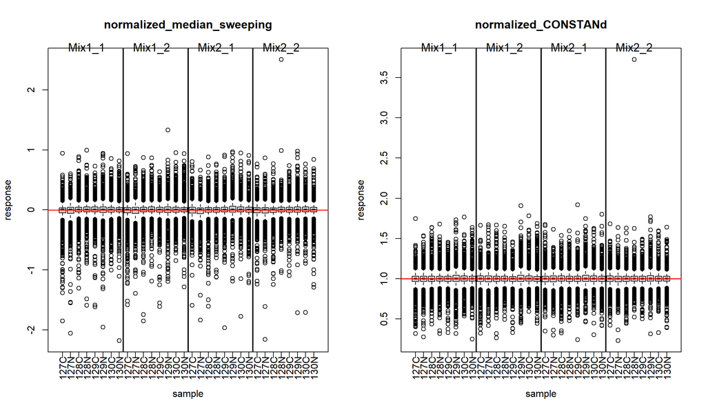

```r
# use (half-)wide format
par(mfrow=c(1,2))
for (i in seq_along(variant.names)) {
  boxplot_w(dat.norm.summ.w[[variant.names[i]]], sample.info, paste('normalized', variant.names[i], sep='_'))}
```

## 5.2 MA plots

MA plots of two single samples taken from condition 1 and condition 0.125, measured in different MS runs (samples *Mixture2_1:127C* and *Mixture1_2:129N*, respectively).

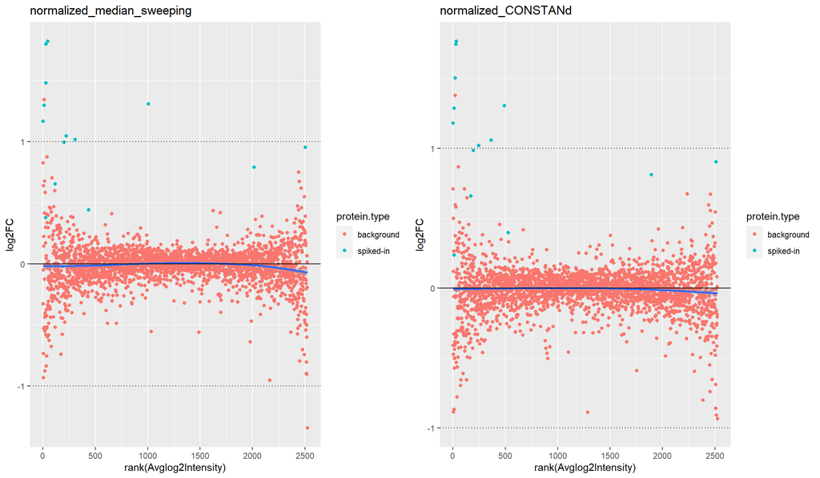

```r
# use wide2 format
p <- emptyList(variant.names)
for (i in 1: n.comp.variants){
  p[[i]] <- maplot_ils(dat.norm.summ.w2[[i]], 'Mixture2_1:127C', 'Mixture1_2:129N', scale.vec[i], paste('normalized', variant.names[i], sep='_'), spiked.proteins)}
grid.arrange(p[[1]], p[[2]], ncol=2)
```

MA plots of all samples from condition `1` and condition `0.125` (quantification values averaged within condition).

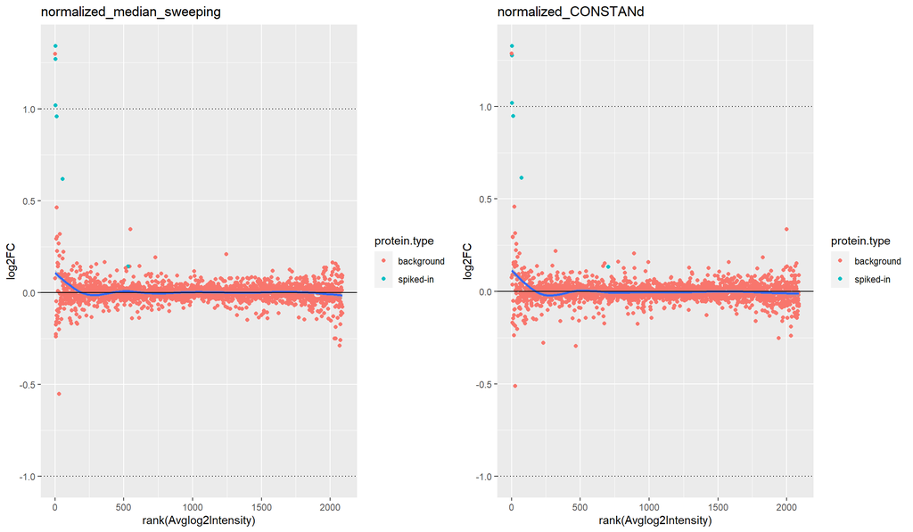

```r
channels.num <- sample.info %>% filter(Condition=='1') %>% select(Sample) %>% pull
channels.denom <- sample.info %>% filter(Condition=='0.125') %>% select(Sample) %>% pull
p <- emptyList(variant.names)
for (i in 1:n.comp.variants){
  p[[i]] <- maplot_ils(dat.norm.summ.w2[[i]], channels.num, channels.denom, scale=scale.vec[i], paste('normalized', variant.names[i], sep='_'), spiked.proteins)}
grid.arrange(p[[1]], p[[2]], ncol=2)
```

## 5.3 PCA plots

### 5.3.1 Using all proteins

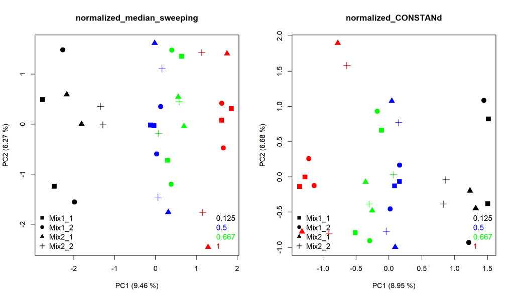

```r
par(mfrow=c(1, 2))
for (i in 1:n.comp.variants){
  pcaplot_ils(dat.norm.summ.w2[[variant.names[i]]] %>% select(-'Protein'), info=sample.info, paste('normalized', variant.names[i], sep='_'))}
```

### 5.3.2 Using spiked proteins only

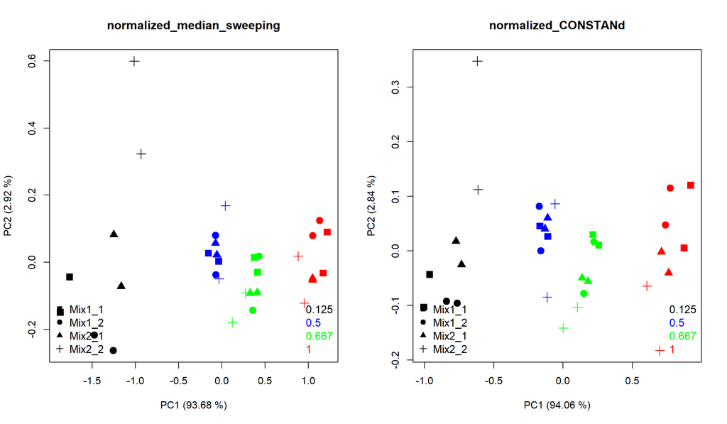

```r
par(mfrow=c(1, 2))
for (i in 1:n.comp.variants){
  pcaplot_ils(dat.norm.summ.w2[[variant.names[i]]] %>% filter(Protein %in% spiked.proteins) %>% select(-'Protein'), info=sample.info, paste('normalized', variant.names[i], sep='_'))}
```

## 5.4 HC (hierarchical clustering) plots

Only use spiked proteins

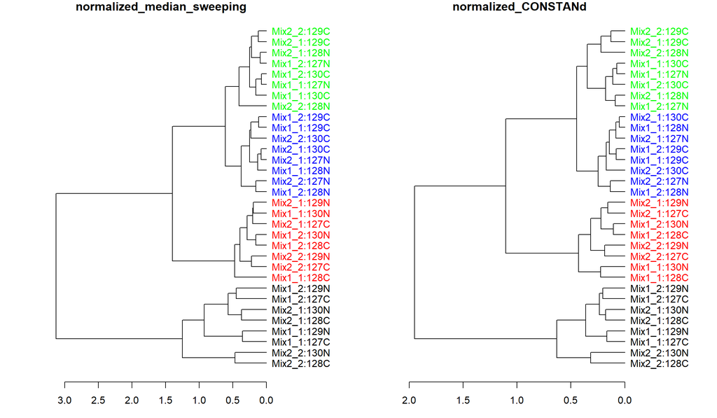

```r
par(mfrow=c(1, 2))
for (i in 1:n.comp.variants){
  dendrogram_ils(dat.norm.summ.w2[[variant.names[i]]] %>% filter(Protein %in% spiked.proteins) %>% select(-Protein), info=sample.info, paste('normalized', variant.names[i], sep='_'))}
```

## 5.5 Run effect p-value plot

Below the histograms of p-values from the linear model explaining the response variable with Run as a covariate.

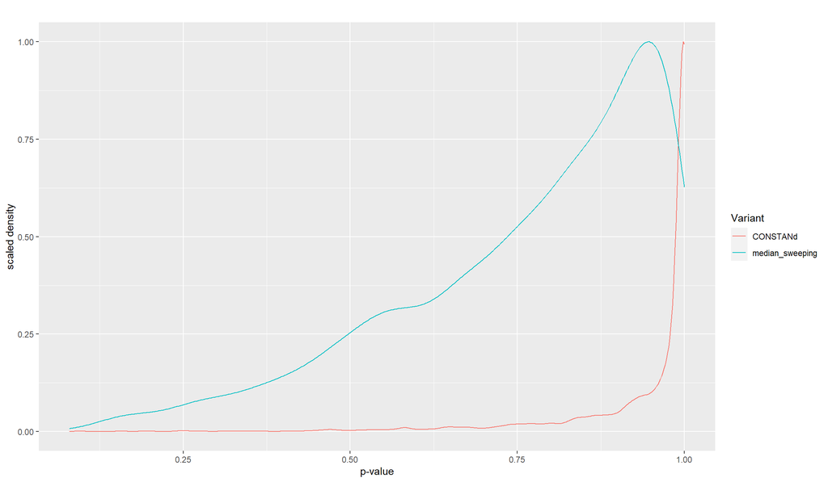

```r
dat <- list(dat.norm.summ.l$median_sweeping, dat.norm.summ.l$CONSTANd)
names(dat) <- c('median_sweeping','CONSTANd')
run_effect_plot(dat)
```

# 6 DEA component: Moderated t-test

NOTE: - actually, lmFit (used in moderated_ttest) was built for log2-transformed data. However, supplying untransformed intensities can also work. This just means that the effects in the linear model are also additive on the untransformed scale, whereas for log-transformed data they are multiplicative on the untransformed scale. Also, there may be a bias which occurs from biased estimates of the population means in the t-tests, as mean(X) is not equal to exp(mean(log(X))).

```r
design.matrix <- get_design_matrix(referenceCondition, sample.info)
dat.dea <- emptyList(names(dat.norm.summ.w2))
for (i in seq_along(dat.norm.summ.w2)) {
  this_scale <- scale.vec[match(names(dat.dea)[i], variant.names)]
  d <- column_to_rownames(as.data.frame(dat.norm.summ.w2[[variant.names[i]]]), 'Protein')
  dat.dea[[variant.names[i]]] <- moderated_ttest(dat=d, design.matrix, scale=this_scale)}
```

# 7 Results comparison

## 7.1 Confusion matrix

```r
cm <- conf_mat(dat.dea, 'q.mod', 0.05, spiked.proteins)
print_conf_mat(cm, referenceCondition)
```

|  | 0.125 vs 0.5 contrast median_sweeping background | 0.125 vs 0.5 contrast median_sweeping spiked | 0.125 vs 0.5 contrast CONSTANd background | 0.125 vs 0.5 contrast CONSTANd spiked |
| --- | --- | --- | --- | --- |
| not_DE | 4061 | 4 | 4062 | 5 |
| DE | 3 | 15 | 2 | 14 |

|  | 0.125 vs 0.5 contrast median_sweeping | 0.125 vs 0.5 contrast CONSTANd |
| --- | --- | --- |
| Accuracy | 0.998 | 0.998 |
| Sensitivity | 0.789 | 0.737 |
| Specificity | 0.999 | 1.000 |
| PPV | 0.833 | 0.875 |
| NPV | 0.999 | 0.999 |

|  | 0.667 vs 0.5 contrast median_sweeping background | 0.667 vs 0.5 contrast median_sweeping spiked | 0.667 vs 0.5 contrast CONSTANd background | 0.667 vs 0.5 contrast CONSTANd spiked |
| --- | --- | --- | --- | --- |
| not_DE | 4062 | 17 | 4063 | 15 |
| DE | 2 | 2 | 1 | 4 |

|  | 0.667 vs 0.5 contrast median_sweeping | 0.667 vs 0.5 contrast CONSTANd |
| --- | --- | --- |
| Accuracy | 0.995 | 0.996 |
| Sensitivity | 0.105 | 0.211 |
| Specificity | 1.000 | 1.000 |
| PPV | 0.500 | 0.800 |
| NPV | 0.996 | 0.996 |

|  | 1 vs 0.5 contrast median_sweeping background | 1 vs 0.5 contrast median_sweeping spiked | 1 vs 0.5 contrast CONSTANd background | 1 vs 0.5 contrast CONSTANd spiked |
| --- | --- | --- | --- | --- |
| not_DE | 4060 | 5 | 4055 | 3 |
| DE | 4 | 14 | 9 | 16 |

|  | 1 vs 0.5 contrast median_sweeping | 1 vs 0.5 contrast CONSTANd |
| --- | --- | --- |
| Accuracy | 0.998 | 0.997 |
| Sensitivity | 0.737 | 0.842 |
| Specificity | 0.999 | 0.998 |
| PPV | 0.778 | 0.640 |
| NPV | 0.999 | 0.999 |

## 7.2 Scatter plots

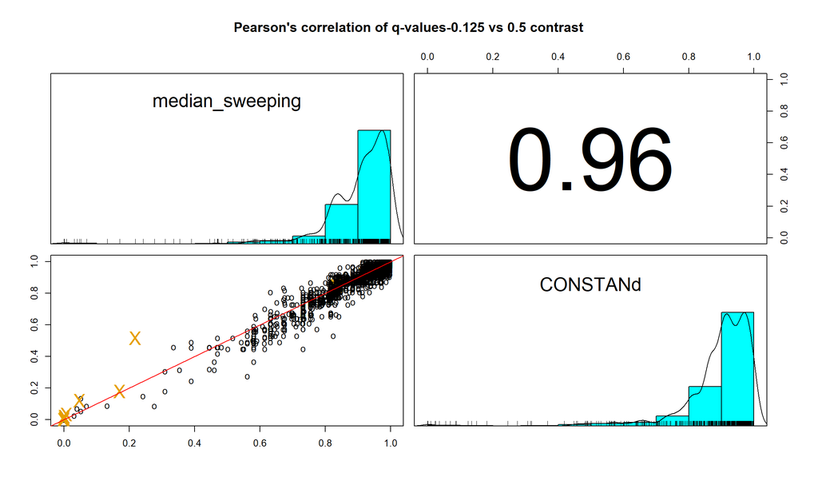

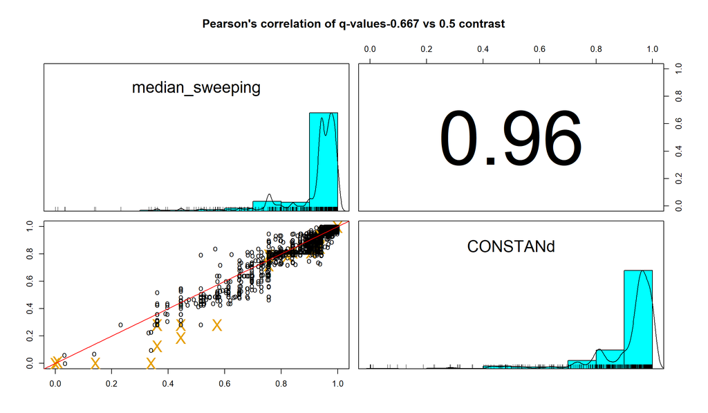

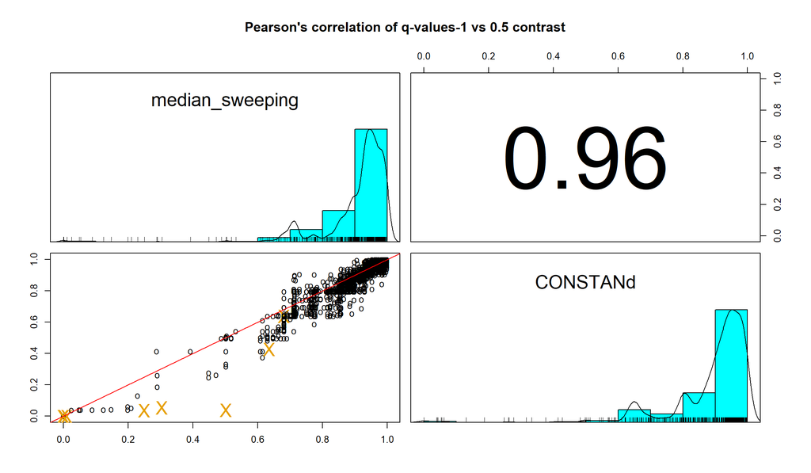

```r
# character vectors containing logFC and p-values columns
dea.cols <- colnames(dat.dea[[1]])
logFC.cols <- dea.cols[stri_detect_fixed(dea.cols, 'logFC')]
significance.cols <- dea.cols[stri_detect_fixed(dea.cols, 'q.mod')]
n.contrasts <- length(logFC.cols)

scatterplot_ils(dat.dea, significance.cols, 'q-values', spiked.proteins)
```

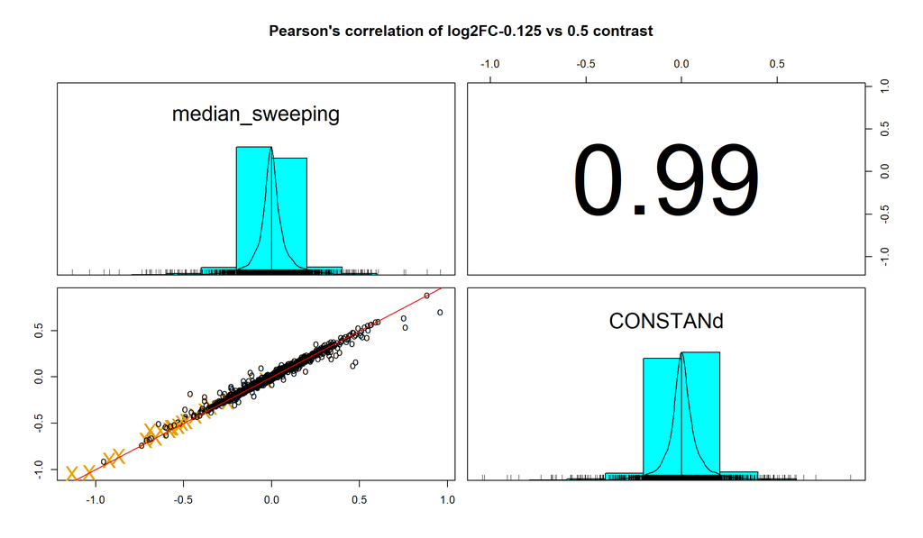

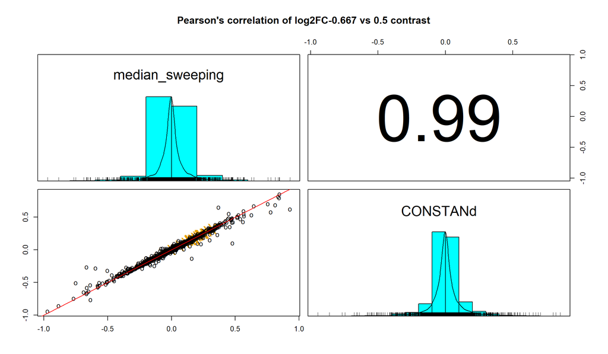

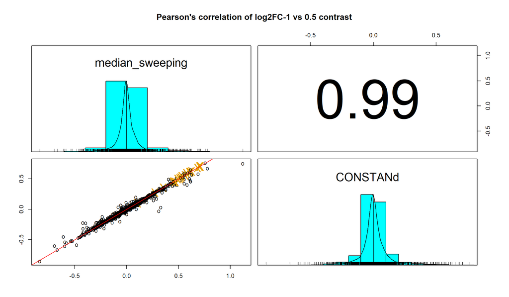

```r
scatterplot_ils(dat.dea, logFC.cols, 'log2FC', spiked.proteins)
```